# 5205HW4

Gehua Zhang (UNI:gz2280)

10/7/2018

#### 3.3.a

```r
data<-read.table("/Users/gehuazhang/Desktop/Data\ Sets/Chapter\ \ 3\ Data\ Sets/CH03PR03.txt")
colnames(data)<-c("GPA","ACT","IQ","RANK")
fit<-lm(data$GPA~data$ACT)
```

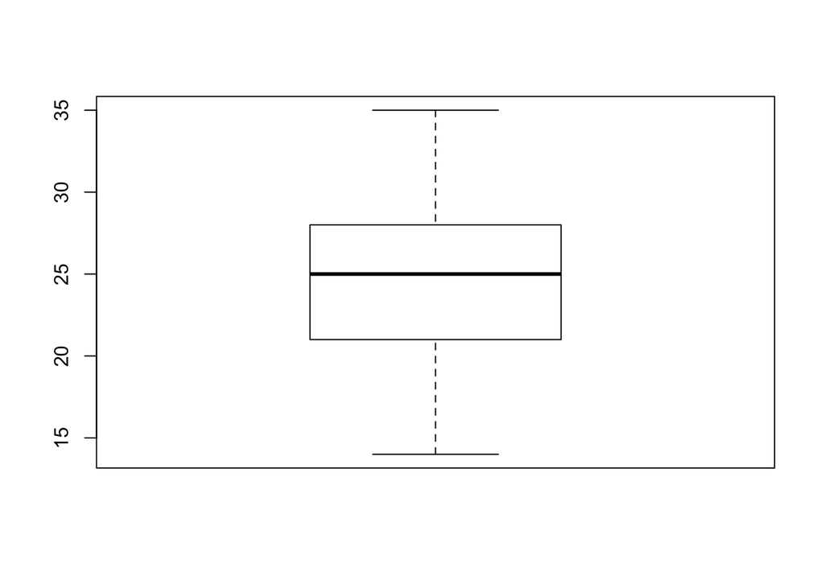

```r
boxplot(data$ACT)
```

From the box plot we can see the range of students’ ACT score, as well as their median, 1st and 3rd quartiles.

Also this graph seems pretty symmetric with no outliers. Looks like randomly sampled from a normal distribution.

#### 3.3.c

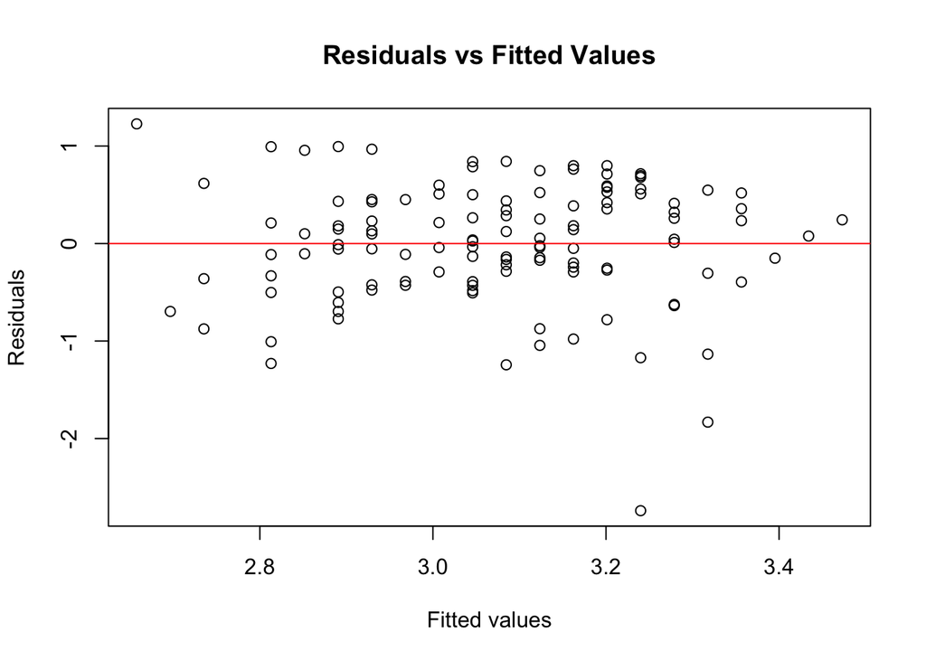

```r
resids <- resid(fit)
plot(predict(fit),fit$resi, main="Residuals vs Fitted Values", xlab="Fitted values", ylab="Residuals")
abline(0,0, col="red")
```

This plot indicates that, the distribution of $e_{i}$ seems no relation to the fitted values $\hat Y_i$, which correspondes our model $Y_i = \beta_1X_i+\beta_0+e_i$ that $e_i$ and $Y_i$ are independent. Also we can conclude that $E(e_i)=0$.

#### 3.3.d

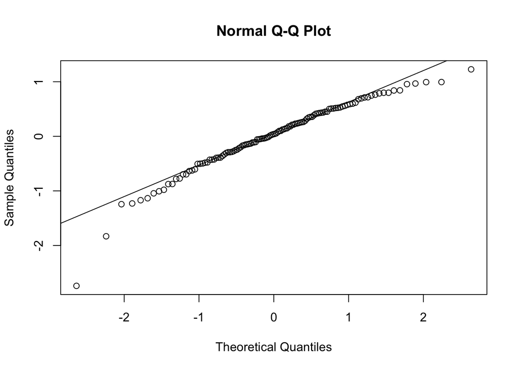

```r
qqnorm(fit$resi)
qqline(fit$resi)
```

```r
library(Hmisc)
```

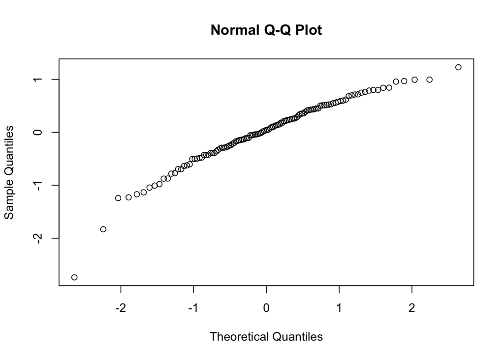

```
## [1] 0.9744497
```

```r
sorted_e <- sort(fit$resi)

expectedResidual <- function(list_residual){
  list_residual <- sort(list_residual)
  n<-length(list_residual)
  MSE <- sum(list_residual^2)/(n-2)
  list_exp_residual=c()

  for (index_residual in c(1:n)){
    z_value<-qnorm((index_residual-0.375)/(n+0.25))
    list_exp_residual<-c(list_exp_residual,sqrt(MSE)*z_value)
  }
  return(list_exp_residual)
}

exp_e <- expectedResidual(fit$resi)
cor(qqnorm(fit$resi)$x,qqnorm(fit$resi)$y)
```

#### 3.3.e

```r
e1 <- fit$resi[data$ACT<26]
e2 <- fit$resi[data$ACT>=26]
n1 <- length(e1)
n2 <- length(e2)
median_e1 <- median(e1)
median_e2 <- median(e2)
d1 <- abs(e1-median_e1)
d2 <- abs(e2-median_e2)
s2 <- (sum((d1-mean(d1))^2) + sum((d2-mean(d2))^2))/(n1+n2-2)
t_star <- (mean(d1)-mean(d2))/(sqrt(s2)*sqrt(1/n1+1/n2))

abs(t_star)
```

```
## [1] 0.8967448
```

```r
qt(1-0.01/2,118)
```

```
## [1] 2.618137
```

Since our $|t^*_{BF}| \le 2.618$, we should conclude that error variance is constant.

This conclusion just matches our findings in part (c).

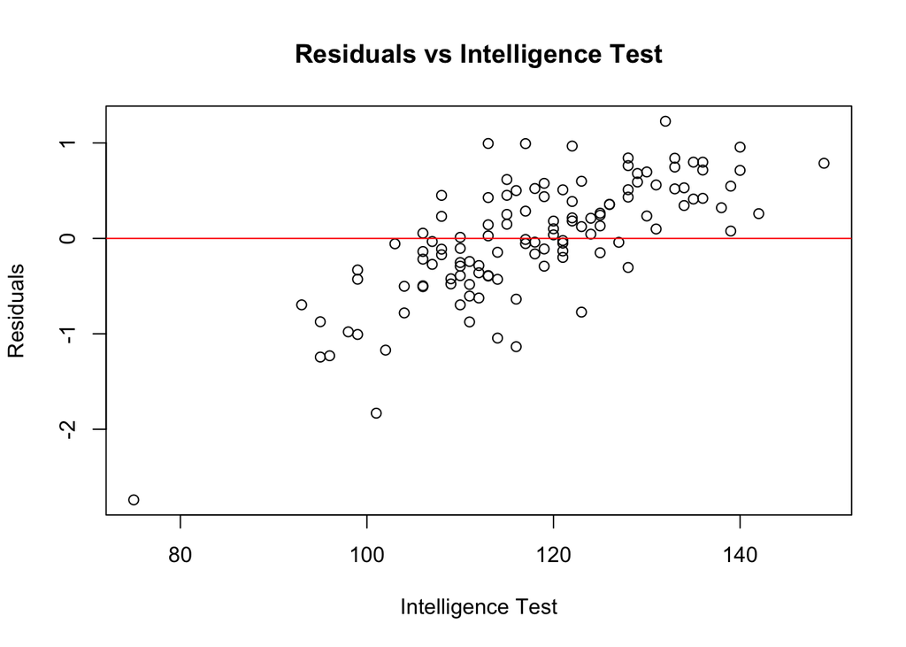

```r
plot(data$IQ,fit$resi,main="Residuals vs Intelligence Test", xlab = "Intelligence Test", ylab = "Residuals")
abline(0,0,col="red")
```

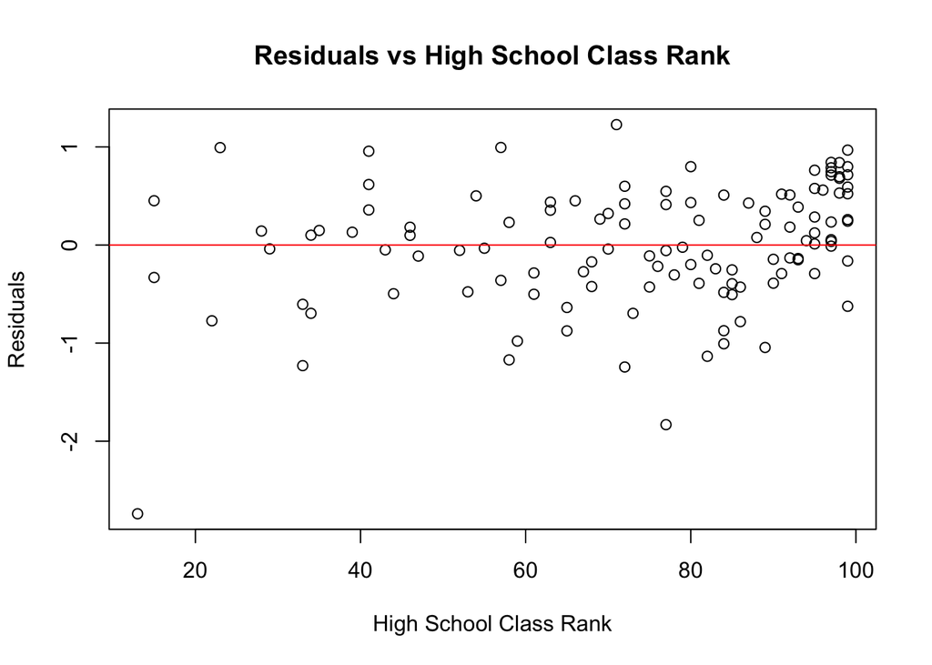

```r
plot(data$RANK,fit$resi,main="Residuals vs High School Class Rank", xlab = "High School Class Rank", ylab = "Residuals")
abline(0,0,col="red")
```

From graphs we conclude that there might exist some relation between residuals and intelligence test, but no many of associations between residuals and high school class ranks. So I would add intelligence test as part of the regression model.

#### 3.16.a

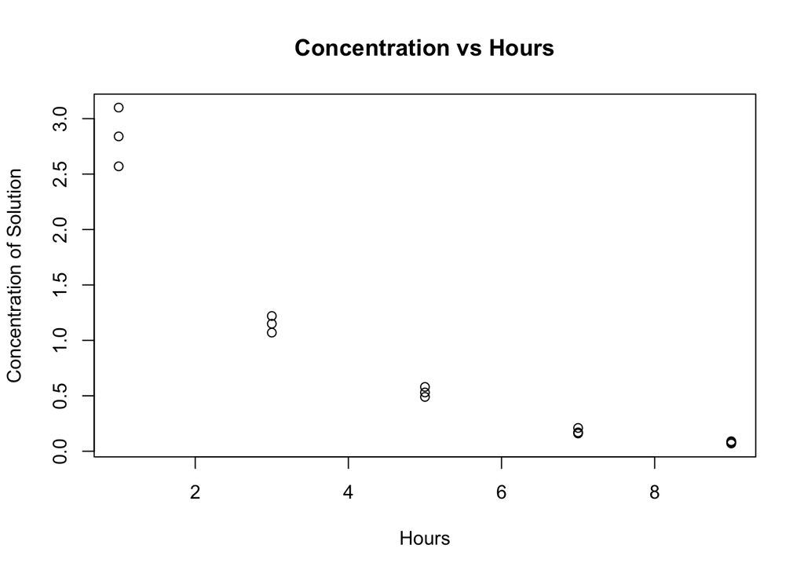

```r
concen_data<-read.table("/Users/gehuazhang/Desktop/Data\ Sets/Chapter\ \ 3\ Data\ Sets/CH03PR15.txt")
colnames(concen_data)<-c("concen","time")
concen_fit <- lm(concen_data$concen~concen_data$time)
plot(concen_data$time,concen_data$concen, main="Concentration vs Hours", xlab="Hours", ylab="Concentration of Solution")
```

I would try take the log value of $Y$ to standardize the variance of $Y$ and obtain a linearity.

#### 3.16.c

```r
y <- log10(concen_data$concen)
log_fit<-lm(y~concen_data$time)
summary(log_fit)
```

```
##
## Call:
## lm(formula = y ~ concen_data$time)
##
## Residuals:
##       Min        1Q    Median        3Q       Max
## -0.082958 -0.044421  0.006813  0.033512  0.085550
##
## Coefficients:
##                   Estimate Std. Error t value Pr(>|t|)
## (Intercept)       0.654880   0.026181   25.01 2.22e-12 ***
## concen_data$time -0.195400   0.004557  -42.88 2.19e-15 ***
## ---
## Signif. codes:  0 '***' 0.001 '**' 0.01 '*' 0.05 '.' 0.1 ' ' 1
##
## Residual standard error: 0.04992 on 13 degrees of freedom
## Multiple R-squared:  0.993,  Adjusted R-squared:  0.9924
## F-statistic:  1838 on 1 and 13 DF,  p-value: 2.188e-15
```

#### 3.16.d

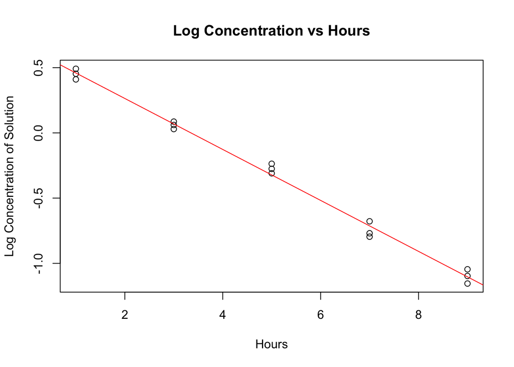

```r
plot(concen_data$time,y,main="Log Concentration vs Hours", xlab="Hours", ylab="Log Concentration of Solution")
abline(log_fit$coefficients, col="red")
```

This seems to be a very good fit.

#### 3.16.e

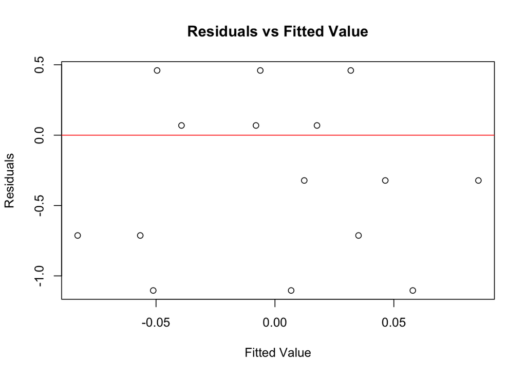

```r
plot(log_fit$resi, predict(log_fit), main="Residuals vs Fitted Value", xlab="Fitted Value", ylab="Residuals")
abline(0,0, col= "red")
```

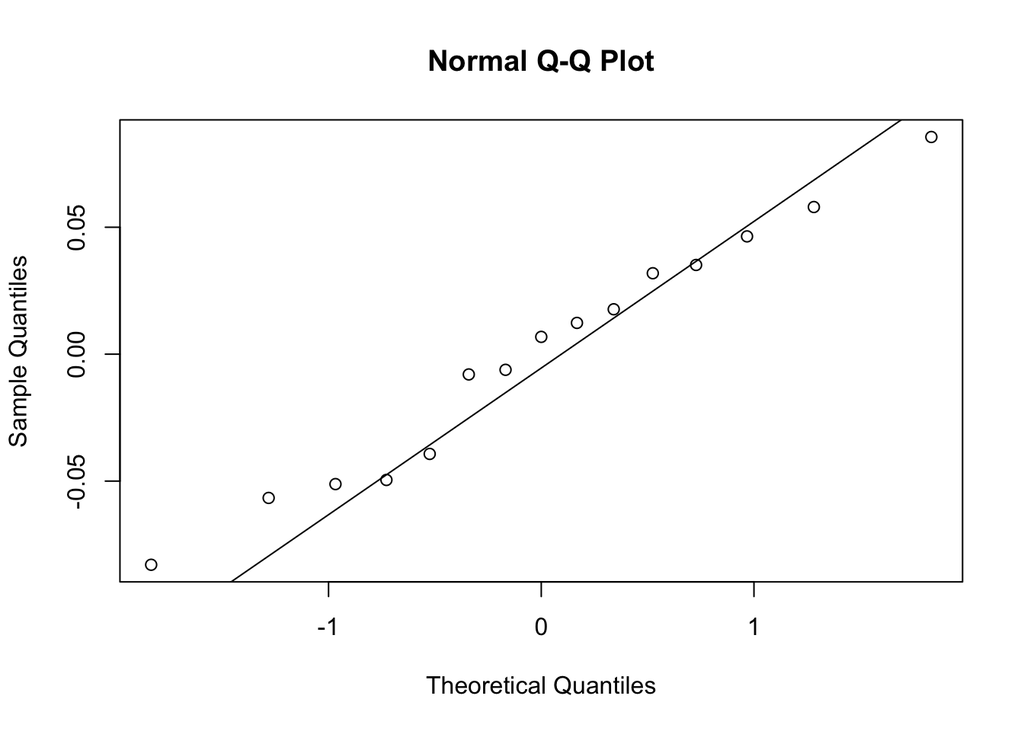

```r
qqnorm(log_fit$resi)
qqline(log_fit$resi)
```

The Q-Q plot indicates that residuals are closely distributed around a linear line, which states that our residuals are randomly distributed.

#### 3.16.f

Our origin model should be
$$Y = 10^{-0.195400*X+0.654880}$$

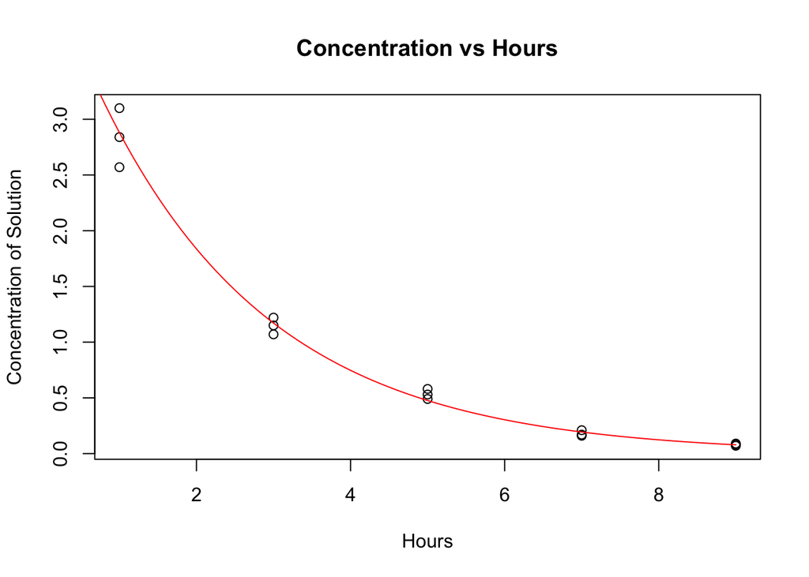

```r
origin_fit <- function(x){
  return(10^(log_fit$coefficients[2]*x+log_fit$coefficients[1]))
}


plot(concen_data$time,concen_data$concen,main="Concentration vs Hours", xlab="Hours", ylab="Concentration of Solution")
curve(10^(log_fit$coefficients[2]*x+log_fit$coefficients[1]),0,9, col="red",add=TRUE)
```